# 等周不等式相关

Simon Brendle

2021/3/31

# 1 背景知识

- $4\pi A\leq L^2$
- 区域上的等周不等式 (全测地)
  $$n\mathbf{vol}(S)^{\frac{n-1}{n}}\mathbf{vol}(B_1)^{\frac{1}{n}}\leq \mathbf{Area}(S)$$
- 方法一
  1. jakob steiner 对称化方法, 约化为凸集.
  2. Brunn-minkowski 不等式
- 推广
  1. 区域(全测地子流形)
  2. 极小子流形
  3. cartan-hadamard 流形
- 方法二
  1. stokes 公式
     $$\int_\Omega div(x)=\int_{\partial{\Omega}}\langle x,\eta\rangle$$
  2. 保体积变分(曲面具有常平均曲率)

# 2 有关欧式空间中极小子流形的等周不等式

Simon Brendle

> 本文证明了一个有关欧式空间中子流形的 Sobolev 不等式. 当余维数为至多为 2 时, 这个不等式是最优的, 若该子流形还是极小的, 则得到了一个最优的等周不等式.

## 2.1 定理 1

> $\Sigma^n$ 为 $\mathbb{R}^{n+p}$ 的紧致子流形，有可能带边，其中 $p\geq2$。若 $f$ 为 $\Sigma^n$ 上的任意正值光滑函数，则有如下不等式成立
> $$\int_{\Sigma}\sqrt{|\nabla^{\Sigma}f|^2+f^2|H|^2}+\int_{\partial{\Sigma}}f \geq
> n\Big\vert\frac{(n+p)|B^{n+p}|}{p|B^p|}\Big\vert^\frac{1}{n}
> (\int_{\Sigma}f^{\frac{n}{n-1}})^{\frac{n-1}{n}}$$
> 其中 $H$ 为子流形的平均曲率向量， $B^n$ 为 $n$ 维单位开球。
- 单位球的体积
  $$\alpha(n)=\frac{\pi^{\frac n2}}{\Gamma(\frac n2+1)}$$
- 作为 Sobolev 不等式的推广.
- $p=2$ 时, 推论2 成立.

## 2.2 定理 1 的证明

- 待证明不等式
  $$\int_{\Sigma}\sqrt{|\nabla^{\Sigma}f|^2+f^2|H|^2}+\int_{\partial{\Sigma}}f \geq
  n\Big(\frac{(n+p)|B^{n+p}|}{p|B^p|}\Big)^\frac{1}{n}
  (\int_{\Sigma}f^{\frac{n}{n-1}})^{\frac{n-1}{n}}$$
- 存在对于 $f$ 的放缩, 使得(先固定某个连通分支)
  $$\int_{\Sigma}\sqrt{|\nabla^{\Sigma}f|^2+f^2|H|^2}+\int_{\partial{\Sigma}}f =
  n\int_{\Sigma}f^{\frac{n}{n-1}}$$
- 只需证明 ($f$ 与放缩有关)
  $$\int_{\Sigma}f^{\frac{n}{n-1}}\geq
  \frac{(n+p)|B^{n+p}|}{p|B^p|}$$
- 流形上其他边值的椭圆方程
  $$\left\{
  \begin{aligned}
  div_{\Sigma}(f\nabla^{\Sigma}u)&=nf^{\frac{n}{n-1}}-
  \sqrt{|\nabla^{\Sigma}f|^2+f^2|H|^2}\quad\text{in }{\Sigma}^n\\
  \langle \nabla^{\Sigma}u,\eta\rangle&=1\qquad \text{in }
  \partial{\Sigma}
  \end{aligned}
  \right
  .$$
  由椭圆正则性理论, $u\in C^{2,\gamma},0<\gamma<1.$ 这里 $u$ 包含了放缩后 $f$ 的信息.
- 特殊区域
  $$\Omega:=\big\{ x\in{\Sigma}\big|\quad|\nabla^{{\Sigma}}u|<1\big\},\\
  U:=\big\{ (x,y)\big|\quad x\in{\Sigma},y\in T_x^\perp{\Sigma},|\nabla^{{\Sigma}}u|^2+|y|^2<1\big\},\\
  A:=\big\{(x,y)\in U\big\vert\quad D^2_{{\Sigma}}u(x)-
  \langle h(x),y\rangle\geq 0\big\}.$$
  向量值函数
  $$\Phi:U\to\mathbb{R}^{n+p}\\
  \Phi(x,y)=\nabla^\Sigma u(x)+y$$
  $\Phi\in C^{1,\gamma},|\Phi|<1.$
- $\Phi(A)=B^{n+p}$(引理 4)

  **proof**

[figure not shown]

- $\det D\Phi(x,y)=\det(D^2_\Sigma u(x)-\langle h(x),y\rangle)$ 在 $U$ 上成立.(引理 5)
- $0\leq\det D\Phi(x,y)\leq f(x)^{\frac{n}{n-1}}$ 在 $A$ 上成立.(引理6)

## 2.3 推论 2

> $\Sigma^n$ 为 $\mathbb{R}^{n+2}$ 的紧致子流形, 有可能带边. 若 $f$ 为 $\Sigma^n$ 上的任意正值光滑函数, 则有如下不等式成立
> $$\int_{\Sigma}\sqrt{|\nabla^{\Sigma}f|^2+f^2|H|^2}+\int_{\partial{\Sigma}}f \geq
> n\Big\vert B^{n}\Big\vert^\frac{1}{n}
> (\int_{\Sigma}f^{\frac{n}{n-1}})^{\frac{n-1}{n}}$$
> 其中 $H$ 为子流形的平均曲率向量， $B^n$ 为 $n$ 维单位开球。

## 2.4 定理 3

> $\Sigma^n$ 为 $\mathbb{R}^{n+2}$ 的紧致子流形，有可能带边。 $f$ 为 $\Sigma^n$ 上的任意正值光滑函数，若如下等式成立
> $$\int_{\Sigma}\sqrt{|\nabla^{\Sigma}f|^2+f^2|H|^2}+\int_{\partial{\Sigma}}f \geq
> n\Big\vert B^{n}\Big\vert^\frac{1}{n}
> (\int_{\Sigma}f^{\frac{n}{n-1}})^{\frac{n-1}{n}}$$
> 则有 $f$ 为常值函数且 $\Sigma^n$ 为 flat round ball.

# 3 brendle 不等式常数的优化

- 体积等式
  $$\frac{(n+p)|B^{n+p}|}{p|B^p|}=\frac n2|B^{n}|\mathcal{B}(\frac n2,\frac p2)$$
- brendle 不等式

$$|B^{n+p}|(1-\sigma^{n+p})\leq|B^{p}|\int_\Omega\Big[(1-|\nabla^\Sigma u|^2)^{\frac p2}-(\sigma^2-|\nabla^\Sigma u|^2)_+^{\frac p2}\Big]f(x)^
{\frac{n}{n-1}}d\mathbf{vol}(x)$$
$\frac p2=k,\sigma\to1$,

$$\frac{(n+p)|B^{n+p}|}{p|B^p|}\leq\int_\Omega(1-|\nabla^\Sigma u|^2)^{k-1}
f(x)^
{\frac{n}{n-1}}d\mathbf{vol}(x)$$
也就是

$$\frac n2|B^{n}|\mathcal{B}(\frac n2,\frac p2)\leq\int_\Omega(1-|\nabla^\Sigma u|^2)^{k-1}f(x)^
{\frac{n}{n-1}}d\mathbf{vol}(x)$$
当 $f$ 为常值函数时

$$\frac n2|B^{n}|\mathcal{B}(\frac n2,\frac p2)V(\Omega)\leq
\int_\Omega(1-|\nabla^\Sigma u|^2)^{k-1}d\mathbf{vol}(x)
\int_\Omega f^
{\frac{n}{n-1}}d\mathbf{vol}(x)$$
**若有?**
$$\frac n2\mathcal{B}(\frac n2,k)V(\Omega)\geq
\int_\Omega(1-|\nabla^\Sigma u|^2)^{k-1}d\mathbf{vol}(x)$$
则有
$$|B^{n}|\leq\int_\Omega f^{\frac{n}{n-1}}d\mathbf{vol}(x)$$
令 $t=|\nabla^\Sigma u|^2$, 则由余面积公式
$$\int_\Omega(1-|\nabla^\Sigma u|^2)^{k-1}d\mathbf{vol}(x)=
\int_\Omega(1-t)^{k-1}\frac{1}{|\nabla\sqrt{t}|}|\nabla\sqrt{t}|
\ d\mathbf{vol}(x)\\
=\int^1_0\int_{|\nabla^\Sigma u|^2=t}(1-t)^{k-1}
\frac{1}{|\nabla\sqrt{t}|}d\sqrt{t}\\
=\int^1_0(1-t)^{k-1}\int_{|\nabla^\Sigma u|^2=t}
\frac{1}{|\nabla t|}dt
\\
\text{如果有}\int_{|\nabla^\Sigma u|^2=t}
\frac{1}{|\nabla t|}\leq\frac n2V(\Omega)t^{\frac{n}2-1}\\
\leq\frac n2V(\Omega)\int^1_0t^{\frac{n}2-1}(1-t)^{k-1}dt\\
=\frac n2\mathcal{B}(\frac n2,k)V(\Omega)$$

- 待证明不等式

$$\int_{|\nabla^\Sigma u|^2=t}
\frac{1}{|\nabla t|}\leq\frac n2V(\Omega)t^{\frac{n}2-1}$$
其中 $t=|\nabla^\Sigma u|^2$, $u$ 满足如下椭圆方程

$$\Delta_\Sigma u=\frac{A(\partial\Sigma)}{V(\Sigma)}\quad in\ \Sigma\\
\langle\nabla^\Sigma u,\eta\rangle=1 \quad on\ \partial\Sigma$$

# 4 一般黎曼流形上的等周不等式

考虑黎曼流形 $N^{n+p}$ 的带边的具有有限体积的子流形 $M^n$, 即如下等距浸入.
$$f: M^n\longrightarrow N^{n+p}$$

## 4.1 stokes 公式

其联系了边界测度与内部测度的关系.

$$\int_{\Omega} \mathbf{div}_M X=\int_{\partial{\Omega}}
\langle X,\eta\rangle$$
其中 $X$ 为 $M$ 上的光滑向量场, $\eta$ 为边界相对于子流形 $M$ 的外法向量.

## 4.2 子流形体积的变分公式

$M$ 光滑流形, $N$ 黎曼流形.

$\phi: M^n\to (N^{n+p},D)$ 为秩 $n$ 光滑映射.

拉回丛: $\phi^{-1}TN$ 决定了 $\phi$ 的变分向量场的取值范围.

- 变分

$$\phi_t=\phi(x,t): M^n\to (N^{n+p},D)\\
v=\frac{\rm{d}\phi_t}{\rm{d}t}{\huge|}_{t=0}\in\Gamma(\phi^{-1}TN)\\
\eta=v{\big|}_{\partial{\Omega}}$$

- 诱导度量

在 $M$ 的局部坐标下$(U,x^i)$
$$(g_t)_{ij}=\langle (\phi_t)_*(\frac{\partial}{\partial{x^i}}),
(\phi_t)_*(\frac{\partial}{\partial{x^j}})
\rangle_N\\
g=g_0$$

- 体积

$$V_N(\phi_t(M))=\int_M\sqrt{\rm{det}g_t}\ {\rm{d}}x^1\cdots
{\rm{d}}x^n$$

- 临界点

$$\begin{align}
\frac{\rm{d}}{\rm{d}t}V_N(\phi_t(M)){\huge|}_{t=0}&=
\int_M\frac{\rm{d}}{\rm{d}t}\sqrt{\rm{det}g_t}{\huge|}_{t=0}{\rm{d}}x^1\cdots{\rm{d}}x^n\\
&= \int_M{\rm{det}g_t}{\rm{tr}}({\rm{g}}_t^{-1}\frac{{\rm{d}g_t}}{\rm{d}t}){\huge|}_{t=0}{\rm{d}}x^1\cdots{\rm{d}}x^n\\
&= \int_M{\rm{tr}}({\rm{g}}^{-1}\frac{{\rm{d}g_t}}{\rm{d}t})
{\rm{det}g}\ {\rm{d}}x^1\cdots{\rm{d}}x^n{\huge|}_{t=0}\\
&= \frac{\rm{d}}{\rm{d}t}\int_M{\rm{tr}}({\rm{g}}^{-1}{\rm{}g_t})
{\rm{det}g}\ {\rm{d}}x^1\cdots{\rm{d}}x^n{\huge|}_{t=0}\\
&= \frac{\rm{d}}{\rm{d}t}\int_M{\rm{}g^{ij}}\langle (\phi_t)_*(\frac{\partial}{\partial{x^i}}),
(\phi_t)_*(\frac{\partial}{\partial{x^j}})
\rangle_N
{\rm{det}g}\ {\rm{d}}x^1\cdots{\rm{d}}x^n{\huge|}_{t=0}\\
&= \frac{\rm{d}}{\rm{d}t}\int_M\langle{\rm{d}\phi_t},
{\rm{d}\phi_t}\rangle
{\rm{det}g}\ {\rm{d}}x^1\cdots{\rm{d}}x^n{\huge|}_{t=0}\\
&=\frac{\rm{d}}{\rm{d}t}E(\phi_t){\huge|}_{t=0}\\
&= \int_M\langle{\rm{d}}v,{\rm{d}\phi}\rangle
{\rm{det}g}\ {\rm{d}}x^1\cdots{\rm{d}}x^n\\
&=\int_M\langle D_{e_i}v,e_i\rangle\\
&=\int_M\langle D_{e_i}v^T,e_i\rangle+\langle D_{e_i}v^\perp,e_i\rangle\\
&=\int_M {\rm{div}}v^T-\langle v,H\rangle\\
&=\int_{\partial{M}}\langle v,e_n\rangle-\int_M\langle v,H\rangle
\end{align}$$

- 一般记号

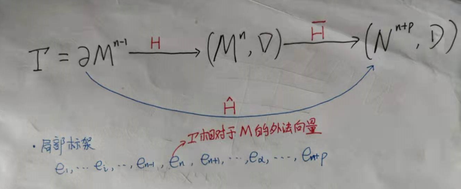

  …

- 两个临界条件(一般黎曼流形的子流形)

$$\begin{align}
\int_\Gamma\langle\eta,e_n\rangle-\int_M\langle v,\bar{H}\rangle=0\\
\int_\Gamma\langle\eta,\hat{H}\rangle=0\\
\end{align}$$

- 三个平均曲率向量
1. $M\to N$

$$\bar{H}=\langle D_{e_i}e_i,e_\alpha\rangle e_\alpha
+\langle D_{e_n}e_n,e_\alpha\rangle e_\alpha$$

2. $\Gamma\to M$

$$H=\langle D_{e_i}e_i,e_n\rangle e_n$$

3. $\Gamma\to N$

$$\hat{H}=\langle D_{e_i}e_i,e_n\rangle e_n+\langle D_{e_i}e_i,e_\alpha\rangle e_\alpha=\hat{H^n}e_n+
\hat{H^\alpha}e_\alpha$$

## 4.3 $M$ 为极小子流形情形

> 若 $M$ 是极小子流形, 在保体积变分下, $M$ 是 $N$ 的临界点的充要条件是 $\hat{H}^n$ 为常值, $\hat{H^\alpha}=0$.

[figure not shown]

…